# 4. Analyzing Nanopore Run Data

Ellie Weise

2024-09-20

## Overview

Once Nanopore data has been processed into an individual vs. percent methylation table, we can look at both that and the per adaptive region depth value to evaluate the success of the nanopore run.

## Testing Nanopore percent methylation against existing clock

### loading in data and libraries

```r
### Testing Nanopore results with existing model
#load packages
library(tidyverse)
library(glmnet)
library(MASS)
library(paletteer)
library(adegenet)
library(ape)
#load data
load("Output/AgeLengthCpG_modelrun_021524.RData")
agesexmeta <- read.csv("Input/SexAgeMetaData_NanoporeRound2.csv")
#nanopore from run 1
barcode1 <- read.table("Nanopore_depth/Barcode3_21-SS-HIP-5533_v5.bedMethyl",header = F,stringsAsFactors = F)
barcode1 <- subset(barcode1,barcode1$V4 == "m")
barcode1$Barcode <- "Barcode1"
barcode2 <- read.table("Nanopore_depth/Barcode4_20-SS-HS-HYP157_v5.bedMethyl",header = F,stringsAsFactors = F)
barcode2 <- subset(barcode2,barcode2$V4 == "m")
barcode2$Barcode <- "Barcode2"
# nanopore sites from run 2
barcode3 <- read.table("Nanopore_CpG/barcode03_merged.bedMethyl",header = F,stringsAsFactors = F)
barcode3 <- subset(barcode3,barcode3$V4 == "m")
barcode3$Barcode <- "Barcode3"
barcode4 <- read.table("Nanopore_CpG/barcode04_merged.bedMethyl",header = F,stringsAsFactors = F)
barcode4 <- subset(barcode4,barcode4$V4 == "m")
barcode4$Barcode <- "Barcode4"
barcode5 <- read.table("Nanopore_CpG/barcode05_merged.bedMethyl",header = F,stringsAsFactors = F)
barcode5 <- subset(barcode5,barcode5$V4 == "m")
barcode5$Barcode <- "Barcode5"
barcode6 <- read.table("Nanopore_CpG/barcode06_merged.bedMethyl",header = F,stringsAsFactors = F)
barcode6 <- subset(barcode6,barcode6$V4 == "m")
barcode6$Barcode <- "Barcode6"
barcode7 <- read.table("Nanopore_CpG/barcode07_merged.bedMethyl",header = F,stringsAsFactors = F)
barcode7 <- subset(barcode7,barcode7$V4 == "m")
barcode7$Barcode <- "Barcode7"
barcode8 <- read.table("Nanopore_CpG/barcode08_merged.bedMethyl",header = F,stringsAsFactors = F)
barcode8 <- subset(barcode8,barcode8$V4 == "m")
barcode8$Barcode <- "Barcode8"
barcode9 <- read.table("Nanopore_CpG/barcode09_merged.bedMethyl",header = F,stringsAsFactors = F)
barcode9 <- subset(barcode9,barcode9$V4 == "m")
barcode9$Barcode <- "Barcode9"
barcode10 <- read.table("Nanopore_CpG/barcode10_merged.bedMethyl",header = F,stringsAsFactors = F)
barcode10 <- subset(barcode10,barcode10$V4 == "m")
barcode10$Barcode <- "Barcode10"
barcode11 <- read.table("Nanopore_CpG/barcode11_merged.bedMethyl",header = F,stringsAsFactors = F)
barcode11 <- subset(barcode11,barcode11$V4 == "m")
barcode11$Barcode <- "Barcode11"
barcode12 <- read.table("Nanopore_CpG/barcode12_merged.bedMethyl",header = F,stringsAsFactors = F)
barcode12 <- subset(barcode12,barcode12$V4 == "m")
barcode12$Barcode <- "Barcode12"
barcode13 <- read.table("Nanopore_CpG/barcode13_merged.bedMethyl",header = F,stringsAsFactors = F)
barcode13 <- subset(barcode13,barcode13$V4 == "m")
barcode13$Barcode <- "Barcode13"
barcode14 <- read.table("Nanopore_CpG/barcode14_merged.bedMethyl",header = F,stringsAsFactors = F)
barcode14 <- subset(barcode14,barcode14$V4 == "m")
barcode14$Barcode <- "Barcode14"
barcode15 <- read.table("Nanopore_CpG/barcode15_merged.bedMethyl",header = F,stringsAsFactors = F)
barcode15 <- subset(barcode15,barcode15$V4 == "m")
barcode15$Barcode <- "Barcode15"
barcode16 <- read.table("Nanopore_CpG/barcode16_merged.bedMethyl",header = F,stringsAsFactors = F)
barcode16 <- subset(barcode16,barcode16$V4 == "m")
barcode16$Barcode <- "Barcode16"
barcode17 <- read.table("Nanopore_CpG/barcode17_merged.bedMethyl",header = F,stringsAsFactors = F)
barcode17 <- subset(barcode17,barcode17$V4 == "m")
barcode17$Barcode <- "Barcode17"
barcode18 <- read.table("Nanopore_CpG/barcode18_merged.bedMethyl",header = F,stringsAsFactors = F)
barcode18 <- subset(barcode18,barcode18$V4 == "m")
barcode18$Barcode <- "Barcode18"
barcode19 <- read.table("Nanopore_CpG/barcode19_merged.bedMethyl",header = F,stringsAsFactors = F)
barcode19 <- subset(barcode19,barcode19$V4 == "m")
barcode19$Barcode <- "Barcode19"
barcode20 <- read.table("Nanopore_CpG/barcode20_merged.bedMethyl",header = F,stringsAsFactors = F)
barcode20 <- subset(barcode20,barcode20$V4 == "m")
barcode20$Barcode <- "Barcode20"
barcode21 <- read.table("Nanopore_CpG/barcode21_merged.bedMethyl",header = F,stringsAsFactors = F)
barcode21 <- subset(barcode21,barcode21$V4 == "m")
barcode21$Barcode <- "Barcode21"
barcode22 <- read.table("Nanopore_CpG/barcode22_merged.bedMethyl",header = F,stringsAsFactors = F)
barcode22 <- subset(barcode22,barcode22$V4 == "m")
barcode22$Barcode <- "Barcode22"
barcode23 <- read.table("Nanopore_CpG/barcode23_merged.bedMethyl",header = F,stringsAsFactors = F)
barcode23 <- subset(barcode23,barcode23$V4 == "m")
barcode23$Barcode <- "Barcode23"

allbarcodes <- rbind(barcode1,barcode2,barcode3,barcode4,barcode5,barcode6,barcode7,barcode8,
                     barcode9,barcode10,barcode11,barcode12,barcode13,barcode14,barcode15,
                     barcode16,barcode17,barcode18,barcode19,barcode20,barcode21,barcode22,barcode23)

#selecting just percent mod and CpG position
pmall <- allbarcodes[,c(1,3,10,11,19)]

colnames(pmall) <- c("CHROM","END","DEPTH","PERCMOD","Barcode")
pmmeta <- left_join(agesexmeta,pmall,by = "Barcode")
```

### Reformatting to match the Illumina data

```r
#reformatting to match Illumina individual data
pmmeta1 <- pmmeta %>%
  mutate(CpG = paste(CHROM,END,sep = ".")) %>%
  filter(DEPTH > 20) %>%
  dplyr::select(Indiv,Sex,Age,Barcode,CpG,PERCMOD) %>%
  spread(key = CpG, value = PERCMOD) %>%
  arrange(Barcode)

pmmeta_long <- pmmeta %>%
  mutate(CpG = paste(CHROM,END,sep = ".")) %>%
  filter(DEPTH > 20) %>%
  dplyr::select(Indiv,Sex,Age,Barcode,CpG,PERCMOD)

pmmeta_best <- pmmeta_long[which(pmmeta_long$CpG %in% CpGlist_best_comb$CpGlist_best),]

barcodecounts <- pmmeta_long %>%
  group_by(Barcode) %>%
  summarise(counts=n())

CpGcounts <- pmmeta_long %>%
  group_by(CpG) %>%
  summarise(counts=n())

## filter low individuals and low SNPs out
pmmeta1 <- pmmeta_long %>%
  filter(Barcode != "Barcode10" & Barcode != "Barcode12") %>%
  spread(key = CpG, value = PERCMOD) %>%
  arrange(Barcode)

bestall <- pmmeta1[,which(colnames(pmmeta1) %in% CpGlist_best_comb$CpGlist_best),]
# count missing data within these sites and remove
bestall1 <- bestall[,colSums(is.na(bestall)) < 10]

meta <- pmmeta1[,1:4]
```

### Running elastic net model with shared sites and predicting nanopore ages

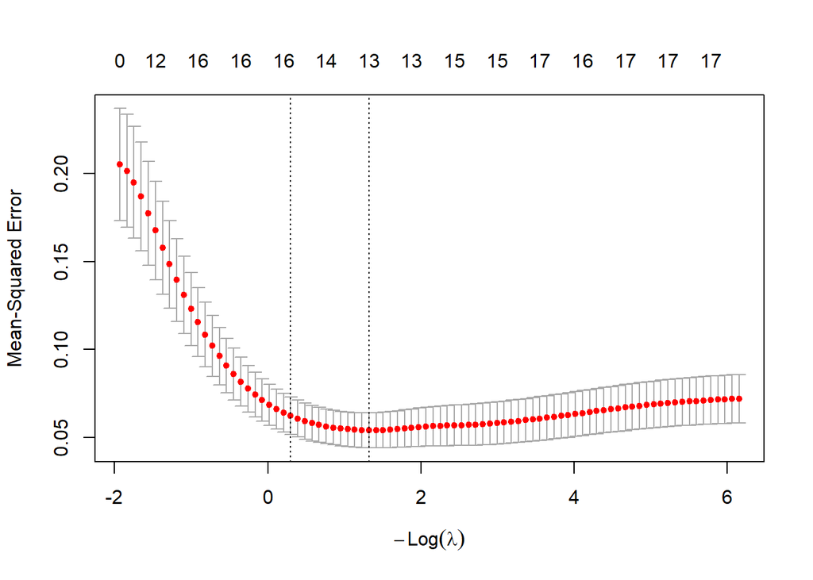

```r
#select data and run glmnet to select sites
y <- traindat$LogAge

#running a glmnet with all selected sites
bestCpG_train <- as.matrix(traindat[,which(colnames(traindat) %in% names(bestall1))])
model1 <- cv.glmnet(bestCpG_train,y,family = "gaussian",alpha = 0.05,nfolds = 10)
coef.allCpG <- as.matrix(coef(model1,s = "lambda.min"))

bestCpGnames <- names(coef.allCpG[which(coef.allCpG > 0),])

#predict testdat
ytest <- c(testdat$LogAge,log(meta$Age))
xtest <- as.matrix(testdat[,which(colnames(testdat) %in% names(bestall1))])
xtest <- as.matrix(rbind(xtest,bestall1))

#predict and correlate train data
pred_logage <- predict(model1,newx = bestCpG_train,type = "response",s = model1$lambda.min)
train_cor <- cor.test(y,pred_logage)
#plot(y,pred_logage,col = traindat$ObsSex)

plot(model1, xvar = "dev", label = TRUE)
```

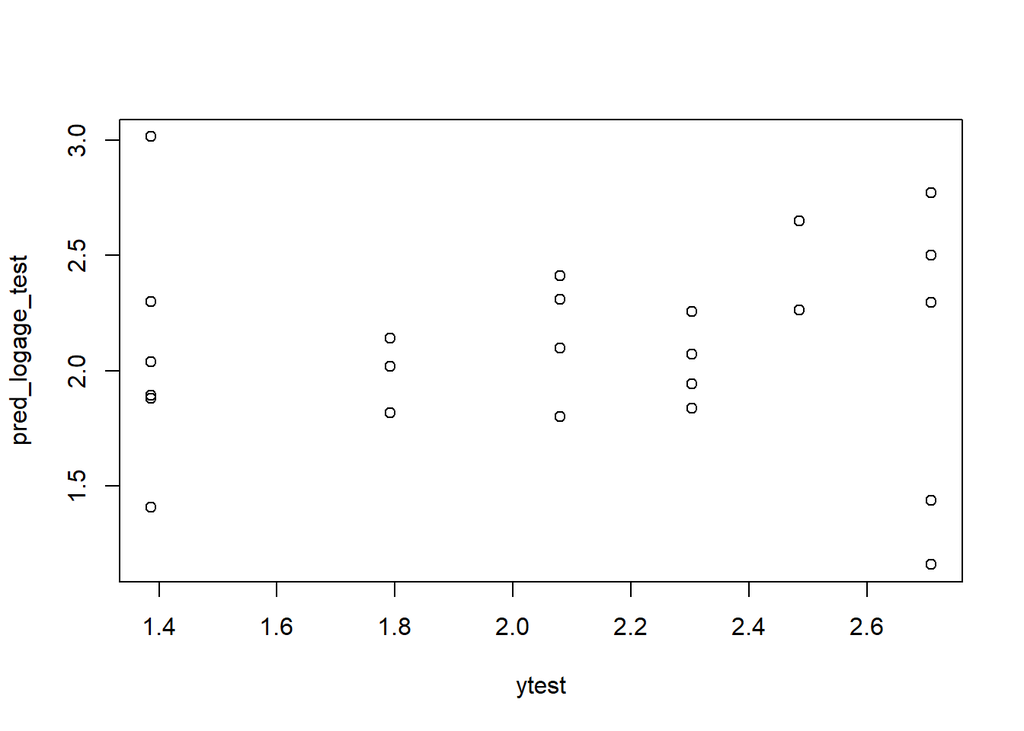

```r
#predict and correlate test data
pred_logage_test <- predict(model1,newx = xtest,type = "response",s = model1$lambda.min)
test_cor <- cor.test(ytest,pred_logage_test)

plot(ytest,pred_logage_test)
```

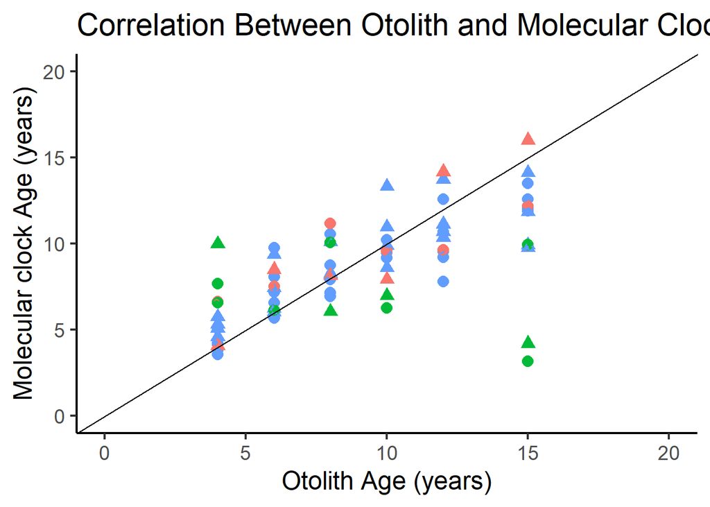

```r
## plotting model with nanopore superimposed
#clock correlation plot
train_res <- data.frame(indivname=traindat$indivname,
                        ObsSex=traindat$ObsSex,
                        LogAge=y,
                        LogEpiAge=pred_logage,
                        type="Train")
colnames(train_res) <- c("indivname","ObsSex","LogAge","LogEpiAge","type")

test_illumina <- data.frame(indivname=testdat$indivname,
                            ObsSex=testdat$ObsSex,
                            LogAge=ytest[1:length(testdat$indivname)],
                            LogEpiAge=pred_logage_test[1:length(testdat$indivname)],
                            type="Test_Illum")
test_nano <- data.frame(indivname=meta$Indiv,
                        ObsSex=meta$Sex,
                        LogAge=ytest[(length(testdat$indivname)+1):length(ytest)],
                        LogEpiAge=pred_logage_test[(length(testdat$indivname)+1):length(ytest)],
                        type="Test_Nano")
res_comb_all <- rbind(train_res,test_illumina,test_nano)
res_comb_all <- res_comb_all %>% mutate(Age=exp(LogAge),EpiAge=exp(LogEpiAge))

ggplot(res_comb_all,aes(x = Age,y = EpiAge,color=type,shape = as.character(ObsSex)))+
  geom_point(size = 3.5)+
  geom_jitter(height = 0,width = 0.1)+
  ylim(0, 20) + xlim(0, 20) +
  geom_abline(slope = 1,intercept = 0) +
  xlab("Otolith Age (years)") +
  ylab("Molecular clock Age (years)") +
  ggtitle("Correlation Between Otolith and Molecular Clock Age") +
  #scale_color_manual(values = c(wes_palette("IsleofDogs1")[1],wes_palette("IsleofDogs1")[3]))+
  theme_classic(base_size = 18) +
  theme(legend.position = "none")
```

Next, we plotted the clock-selected CpG sites for percent methylation values to look for shared relationships even if the percent methylation values are not compatible enough to be included in the same clock

```r
# data frames with only duplicated individuals at shared CpG sites
agesexmeta <- agesexmeta %>% filter(Barcode != "Barcode10" & Barcode != "Barcode12")
illumina <- allCpGs1[which(allCpGs1$indivname %in% agesexmeta$indivname),]
nano_CpGs <- pmmeta1[,which(colnames(pmmeta1) %in% colnames(illumina))]
nano_CpGs$indivname <- pmmeta1$Indiv
nano_CpGs$type <- "Nanopore"
illum_CpGs <- illumina[,which(colnames(illumina) %in% colnames(pmmeta1))]
illum_CpGs$type <- "Illumina"
illum_CpGs$indivname <- illumina$indivname
```

First we ran a basic PCA on individuals sequenced with both methods to establish if there is a potential sequencing effect on percent methylation rates. The primary axis shows two distinct groups separated by type of sequencing.

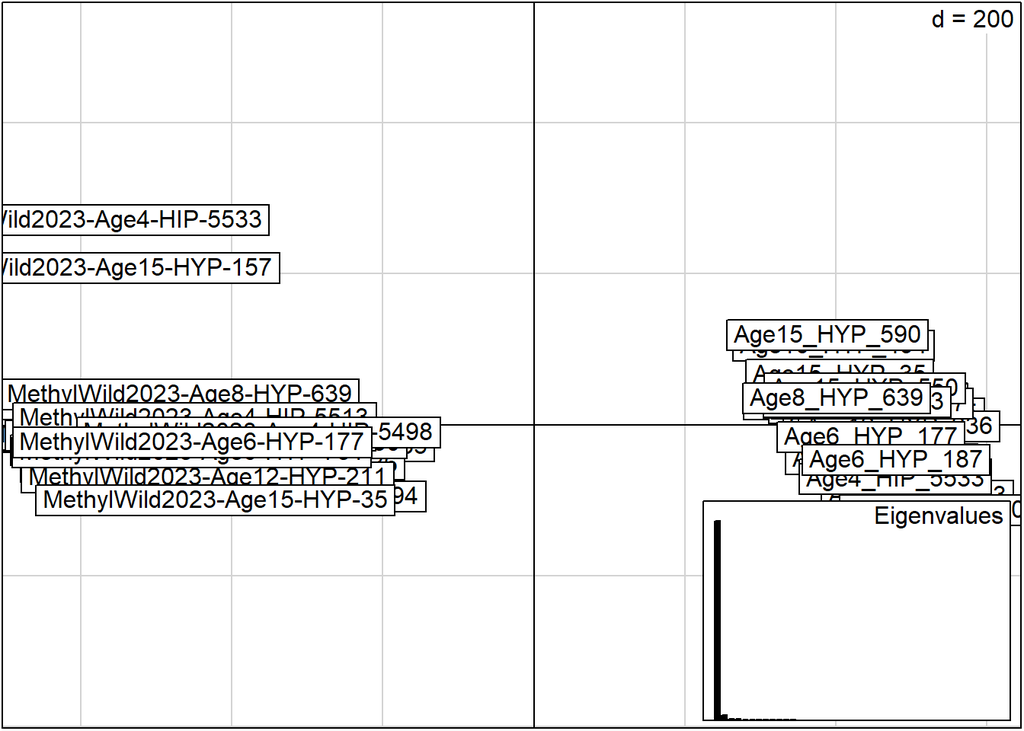

```r
## run PCA to look for sequencing type effect
##make phenotypic sex genlight
#make SNP, indiv, and pop sections of input
all_CpGs <- rbind(nano_CpGs,illum_CpGs)

#look for missing data
all_CpGs <- all_CpGs[,which(colSums(is.na(all_CpGs)) <= 5)]

# make genlight
CpGsSNPs <- all_CpGs %>% dplyr::select(-indivname,-type)
CpGsindiv <- all_CpGs$indivname
CpGspop <- all_CpGs$type
CpGsSNPnames <- colnames(CpGsSNPs)
#make genlight (takes ~1 min)
genCpGs <- new("genlight",
                   CpGsSNPs,
                   ploidy = 2,
                   ind.names = CpGsindiv,
                   loc.names = CpGsSNPnames,
                   pop = CpGspop)

pca1 <- glPca(genCpGs,nf=24)
scatter(pca1, posi="bottomright")
```

```r
tre <- nj(dist(as.matrix(genCpGs)))
tre
```

```
##
## Phylogenetic tree with 42 tips and 40 internal nodes.
##
## Tip labels:
##   MethylWild2023-Age4-HIP-5533, MethylWild2023-Age8-HYP-639, MethylWild2023-Age8-HYP-593, MethylWild2023-Age10-HYP-52, MethylWild2023-Age10-HYP-544, MethylWild2023-Age10-HYP-266, ...
##
## Unrooted; includes branch length(s).
```

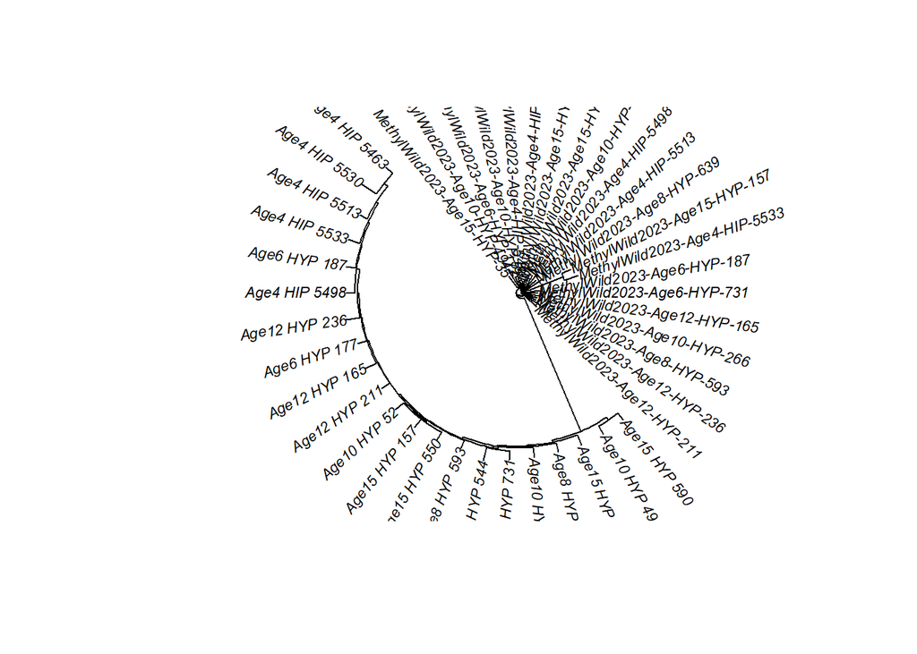

```r
plot(tre, typ="fan", cex=0.7)
```

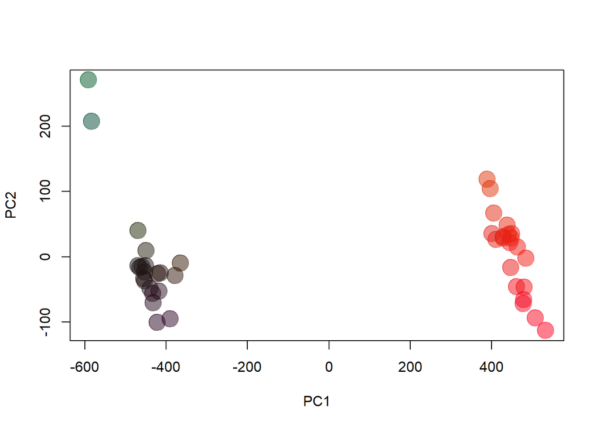

```r
colorplot(pca1$scores,pca1$scores, transp=TRUE, cex=4)
```

```r
## compare the CpG age-specific regions between duplicates
CpGlist_best_comb
```

```
##            CpGlist_best   n
## 1     NC_047151.1.15471 100
## 2  NC_047155.1.30745807  93
## 3      NC_047151.1.7401  87
## 4      NC_047151.1.5724  86
## 5      NC_047151.1.9078  77
## 6      NC_047151.1.6425  69
## 7  NC_047153.1.32663347  68
## 8  NC_047163.1.29070020  64
## 9  NC_047153.1.32669800  63
## 10 NC_047155.1.30745713  63
## 11 NC_047153.1.32668700  52
## 12 NC_047153.1.32663683  51
## 13 NC_047163.1.21495116  49
## 14     NC_047151.1.4742  47
```

[output cut: 75 more lines]

```r
all_CpGs <- rbind(nano_CpGs,illum_CpGs)

best_illum <- illumina[,which(colnames(illumina) %in% CpGlist_best_comb$CpGlist_best)]
best_nano <- nano_CpGs[,which(colnames(nano_CpGs) %in% CpGlist_best_comb$CpGlist_best)]
best_nano$Indiv <- nano_CpGs$indivname
best_nano$type <- "Nanopore"
best_nano <- best_nano %>% left_join(agesexmeta) %>% dplyr::select(-Indiv,-Barcode)
best_illum <- best_illum[,which(colnames(best_illum) %in% colnames(nano_CpGs))]
best_illum$indivname <- illumina$indivname
best_illum$type <- "Illumina"
best_illum <- best_illum %>% left_join(agesexmeta) %>% dplyr::select(-Indiv,-Barcode)
```

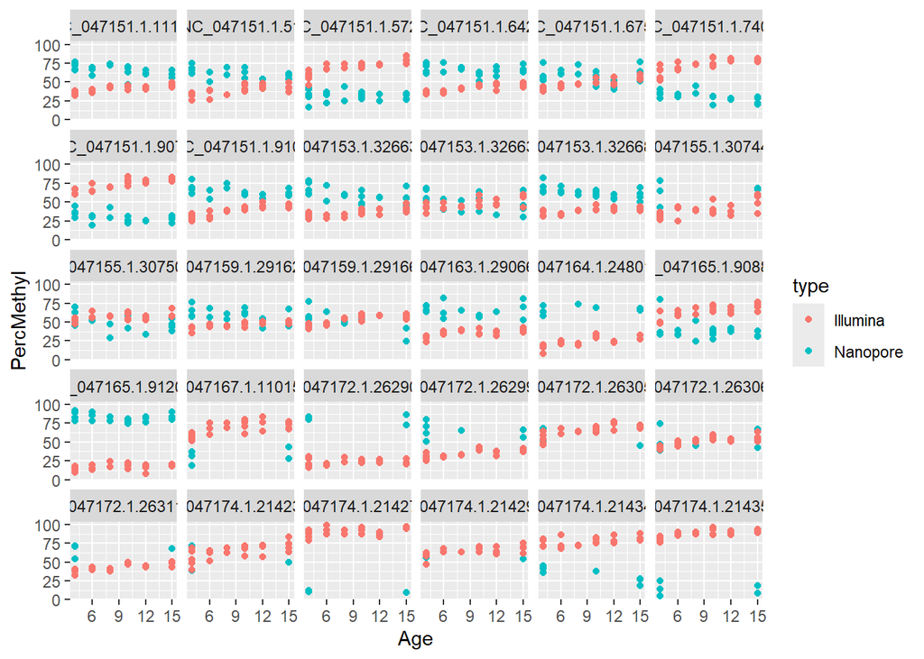

```r
bestCpG <- rbind(best_nano,best_illum)

bestCpG %>%
  gather(key = "CpGsite",value = "PercMethyl",-indivname,-type,-Sex,-Age) %>%
  ggplot(aes(x = Age,y = PercMethyl,color=type))+
    geom_point()+
    facet_wrap(~CpGsite)
```

We then tested the creation of a just-Nanopore calibrated clock, which still has a relatively low sample size, but just enough for basic testing. We wanted to determine if the same CpGs were selected for age prediction across methods, or if different sites were selected, if they were within the same CpG region of the genome.

This is particularly important because as much as the Nanopore sequencing was successful across the 21 individuals, the Dorodo processing software excludes many sites internally, leading to exclusion of many of our desired sites from the data set despite having sufficient depth for CpG calls based on the samtools calculation.

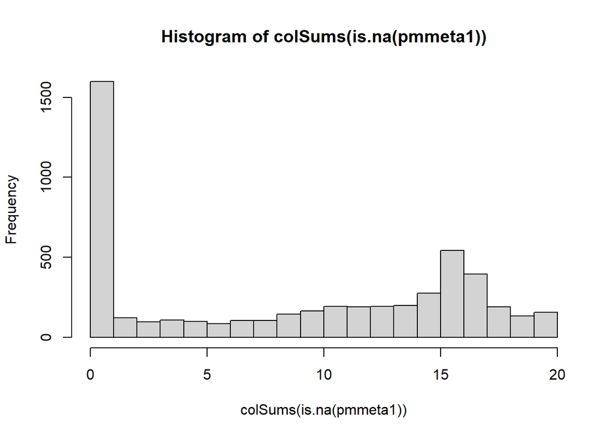

```r
# counting missing data
hist(colSums(is.na(pmmeta1)),breaks = 25)
```

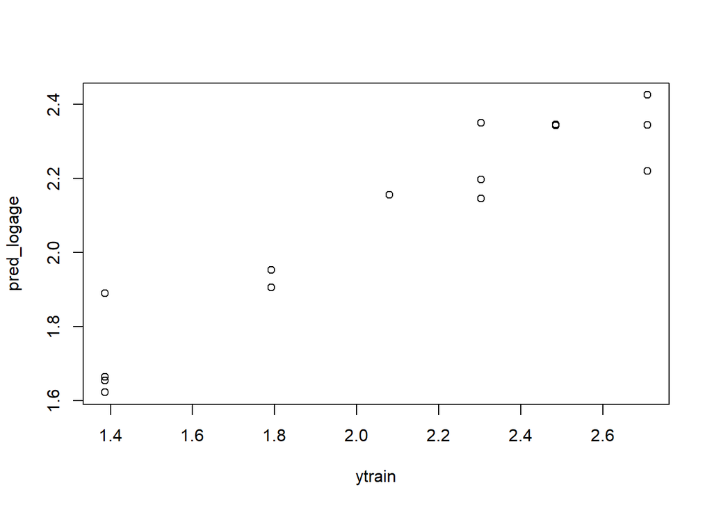

```r
nomiss <- pmmeta1[,which(colSums(is.na(pmmeta1)) == 0)]

# split one individual per age group out for testing
test <- nomiss %>%
  group_by(Age) %>%
  sample_n(1)

train <- nomiss %>%
  filter(!(Indiv %in% test$Indiv))

xtrain <- as.matrix(train[,-1:-4])
ytrain <- log(train$Age)

model2 <- cv.glmnet(xtrain,ytrain,family = "gaussian",alpha = 0.5,nfolds = 5)
coef.allCpG <- as.matrix(coef(model2,s = "lambda.min"))

bestCpGnames <- names(coef.allCpG[which(coef.allCpG > 0),])


#predict testdat
ytest <- log(test$Age)
xtest <- as.matrix(test[,-1:-4])

#predict and correlate train data
pred_logage <- predict(model2,newx = xtrain,type = "response",s = model1$lambda.min)
train_cor <- cor.test(ytrain,pred_logage)
#plot(y,pred_logage,coytest#plot(y,pred_logage,col = traindat$ObsSex)
plot(ytrain,pred_logage)
```

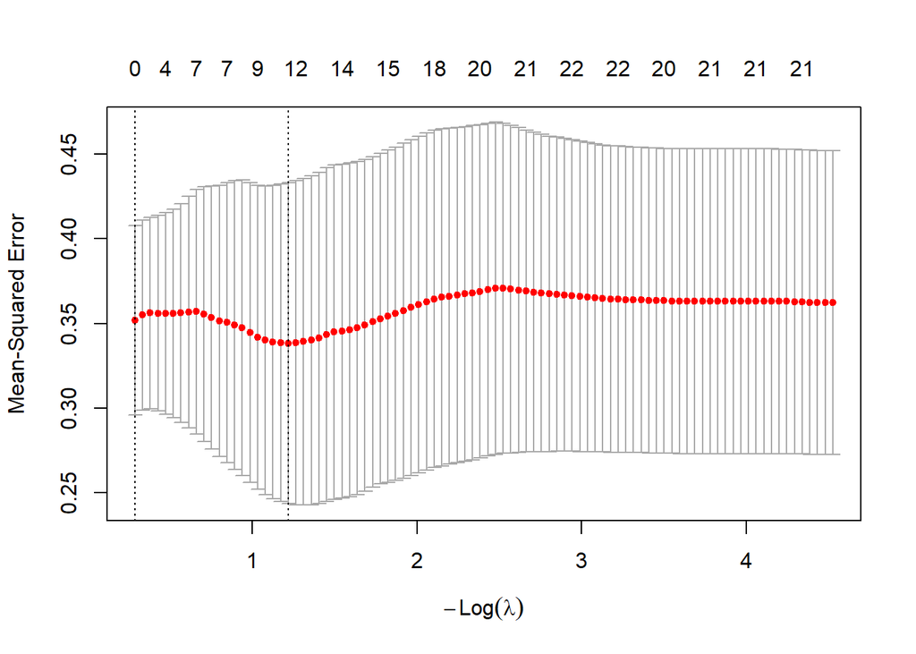

```r
 plot(model2, xvar = "dev", label = TRUE)
```

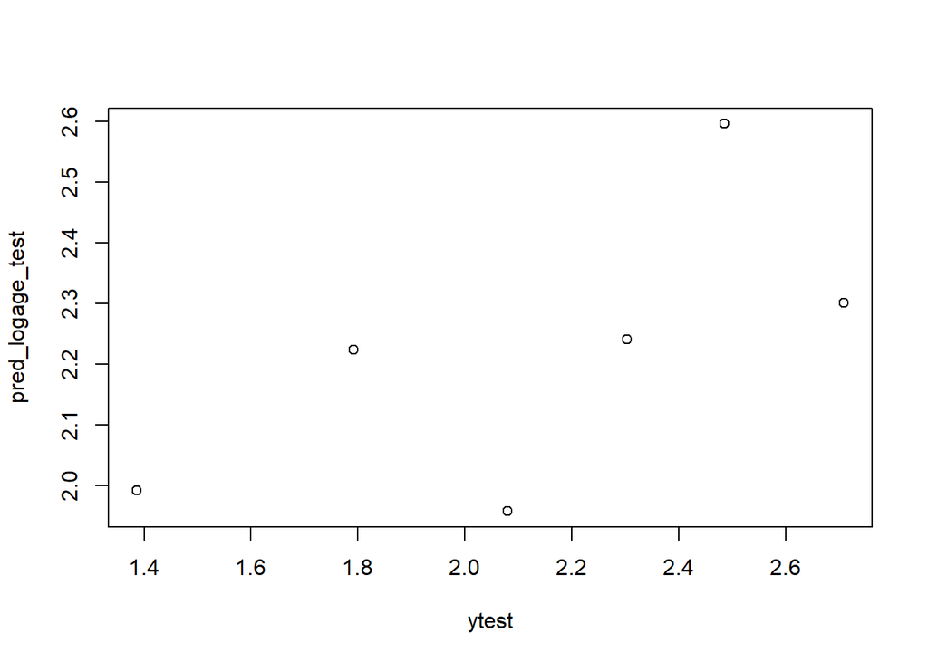

```r
#predict and correlate test data
pred_logage_test <- predict(model2,newx = xtest,type = "response",s = model1$lambda.min)
test_cor <- cor.test(ytest,pred_logage_test)

plot(ytest,pred_logage_test)
```

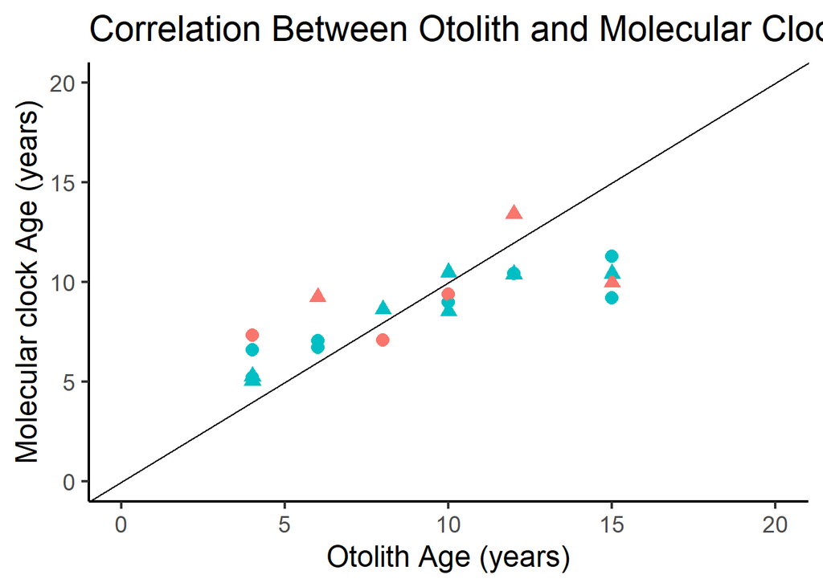

```r
#clock correlation plot
train_res <- data.frame(indivname=train$Indiv,
                        ObsSex=train$Sex,
                        LogAge=ytrain,
                        LogEpiAge=pred_logage,
                        type="Train")
colnames(train_res) <- c("indivname","ObsSex","LogAge","LogEpiAge","type")

test_res <- data.frame(indivname=test$Indiv,
                        ObsSex=test$Sex,
                        LogAge=ytest,
                        LogEpiAge=pred_logage_test,
                        type="Test")
colnames(test_res) <- c("indivname","ObsSex","LogAge","LogEpiAge","type")
res_comb_all <- rbind(train_res,test_res)
res_comb_all <- res_comb_all %>% mutate(Age=exp(LogAge),EpiAge=exp(LogEpiAge))

ggplot(res_comb_all,aes(x = Age,y = EpiAge,color=type,shape = as.character(ObsSex)))+
  geom_point(size = 3.5)+
  geom_jitter(height = 0,width = 0.1)+
  ylim(0, 20) + xlim(0, 20) +
  geom_abline(slope = 1,intercept = 0) +
  xlab("Otolith Age (years)") +
  ylab("Molecular clock Age (years)") +
  ggtitle("Correlation Between Otolith and Molecular Clock Age") +
  #scale_color_manual(values = c(wes_palette("IsleofDogs1")[1],wes_palette("IsleofDogs1")[3]))+
  theme_classic(base_size = 18) +
  theme(legend.position = "none")
```

## Testing per CpG depth for Nanopore Runs

### Reading in depth files and adaptive files

```r
depth3 <- read.table("Nanopore_depth/calls_2025-08-18_T14-08-26_barcode03_depth.txt")
colnames(depth3) <- c("CHROM","POS","DEPTH")
depth3$Barcode <- "Barcode3"

depth4 <- read.table("Nanopore_depth/calls_2025-08-18_T14-20-31_barcode04_depth.txt")
colnames(depth4) <- c("CHROM","POS","DEPTH")
depth4$Barcode <- "Barcode4"

depth5 <- read.table("Nanopore_depth/calls_2025-08-18_T14-23-37_barcode05_depth.txt")
colnames(depth5) <- c("CHROM","POS","DEPTH")
depth5$Barcode <- "Barcode5"

depth6 <- read.table("Nanopore_depth/calls_2025-08-18_T14-41-42_barcode06_depth.txt")
colnames(depth6) <- c("CHROM","POS","DEPTH")
depth6$Barcode <- "Barcode6"

depth7 <- read.table("Nanopore_depth/calls_2025-08-18_T18-37-07_barcode07_depth.txt")
colnames(depth7) <- c("CHROM","POS","DEPTH")
depth7$Barcode <- "Barcode7"

depth8 <- read.table("Nanopore_depth/calls_2025-08-18_T18-37-05_barcode08_depth.txt")
colnames(depth8) <- c("CHROM","POS","DEPTH")
depth8$Barcode <- "Barcode8"

depth9 <- read.table("Nanopore_depth/calls_2025-08-18_T18-37-05_barcode09_depth.txt")
colnames(depth9) <- c("CHROM","POS","DEPTH")
depth9$Barcode <- "Barcode9"

depth10 <- read.table("Nanopore_depth/calls_2025-08-18_T18-37-05_barcode10_depth.txt")
colnames(depth10) <- c("CHROM","POS","DEPTH")
depth10$Barcode <- "Barcode10"

depth11 <- read.table("Nanopore_depth/calls_2025-08-18_T18-41-33_barcode11_depth.txt")
colnames(depth11) <- c("CHROM","POS","DEPTH")
depth11$Barcode <- "Barcode11"

depth12 <- read.table("Nanopore_depth/calls_2025-08-18_T18-47-38_barcode12_depth.txt")
colnames(depth12) <- c("CHROM","POS","DEPTH")
depth12$Barcode <- "Barcode12"

depth13 <- read.table("Nanopore_depth/calls_2025-08-18_T18-50-46_barcode13_depth.txt")
colnames(depth13) <- c("CHROM","POS","DEPTH")
depth13$Barcode <- "Barcode13"

depth14 <- read.table("Nanopore_depth/calls_2025-08-18_T18-51-59_barcode14_depth.txt")
colnames(depth14) <- c("CHROM","POS","DEPTH")
depth14$Barcode <- "Barcode14"

depth15 <- read.table("Nanopore_depth/calls_2025-08-18_T18-53-17_barcode15_depth.txt")
colnames(depth15) <- c("CHROM","POS","DEPTH")
depth15$Barcode <- "Barcode15"

depth16 <- read.table("Nanopore_depth/calls_2025-08-18_T18-56-22_barcode16_depth.txt")
colnames(depth16) <- c("CHROM","POS","DEPTH")
depth16$Barcode <- "Barcode16"

depth17 <- read.table("Nanopore_depth/calls_2025-08-18_T18-57-35_barcode17_depth.txt")
colnames(depth17) <- c("CHROM","POS","DEPTH")
depth17$Barcode <- "Barcode17"

depth18 <- read.table("Nanopore_depth/calls_2025-08-18_T18-59-02_barcode18_depth.txt")
colnames(depth18) <- c("CHROM","POS","DEPTH")
depth18$Barcode <- "Barcode18"

depth19 <- read.table("Nanopore_depth/calls_2025-08-18_T19-00-14_barcode19_depth.txt")
colnames(depth19) <- c("CHROM","POS","DEPTH")
depth19$Barcode <- "Barcode19"

depth20 <- read.table("Nanopore_depth/calls_2025-08-18_T19-01-05_barcode20_depth.txt")
colnames(depth20) <- c("CHROM","POS","DEPTH")
depth20$Barcode <- "Barcode20"

depth21 <- read.table("Nanopore_depth/calls_2025-08-18_T19-03-31_barcode21_depth.txt")
colnames(depth21) <- c("CHROM","POS","DEPTH")
depth21$Barcode <- "Barcode21"

depth22 <- read.table("Nanopore_depth/calls_2025-08-18_T19-06-10_barcode22_depth.txt")
colnames(depth22) <- c("CHROM","POS","DEPTH")
depth22$Barcode <- "Barcode22"

depth23 <- read.table("Nanopore_depth/calls_2025-08-18_T19-06-33_barcode23_depth.txt")
colnames(depth23) <- c("CHROM","POS","DEPTH")
depth23$Barcode <- "Barcode23"

adapt2 <- read.table("Output/NanoporeRegionSelection_061224.txt")
colnames(adapt2) <- c("CHROM", "START", "END")

## rbind and join metadata to depth files
depthall <- rbind(depth3,depth4,depth5,depth6,depth7,depth8,depth9,depth10,depth11,
      depth12,depth13,depth14,depth15,depth16,depth17,depth18,depth19,
      depth20,depth21,depth22,depth23)
```

### match depth to nanopore adaptive regions

```r
## match file to adaptive sequencing
# adapt1$LENGTH <- adapt1$END - adapt1$START
# adapt1$NAME <- paste0(adapt1$CHROM,":",adapt1$START,"-",adapt1$END,",", adapt1$LENGTH)
adapt2$LENGTH <- adapt2$END - adapt2$START
adapt2$NAME <- paste0(adapt2$CHROM,":",adapt2$START,"-",adapt2$END,",", adapt2$LENGTH)

depthall$NAME <- NA

# for (i in 1:nrow(adapt1)) {
#   depth1$NAME[which(depth1$CHROM == adapt1$CHROM[i] &
#                       depth1$POS >= adapt1$START[i] &
#                       depth1$POS < adapt1$END[i])] <- adapt1$NAME[i]
#
#   depth2$NAME[which(depth2$CHROM == adapt1$CHROM[i] &
#                       depth2$POS >= adapt1$START[i] &
#                       depth2$POS < adapt1$END[i])] <- adapt1$NAME[i]
# }

for (i in 1:nrow(adapt2)) {
  depthall$NAME[which(depthall$CHROM == adapt2$CHROM[i] &
                      depthall$POS >= adapt2$START[i] &
                      depthall$POS < adapt2$END[i])] <- adapt2$NAME[i]
}
```

### Put files together

```r
summall <- depthall %>%
  group_by(Barcode,NAME) %>%
  summarise(avg1 = mean(DEPTH),
            med1 = median(DEPTH)) %>%
  separate(col = NAME,into = c("NAME","LENGTH"),sep = ",")
```

### Figures

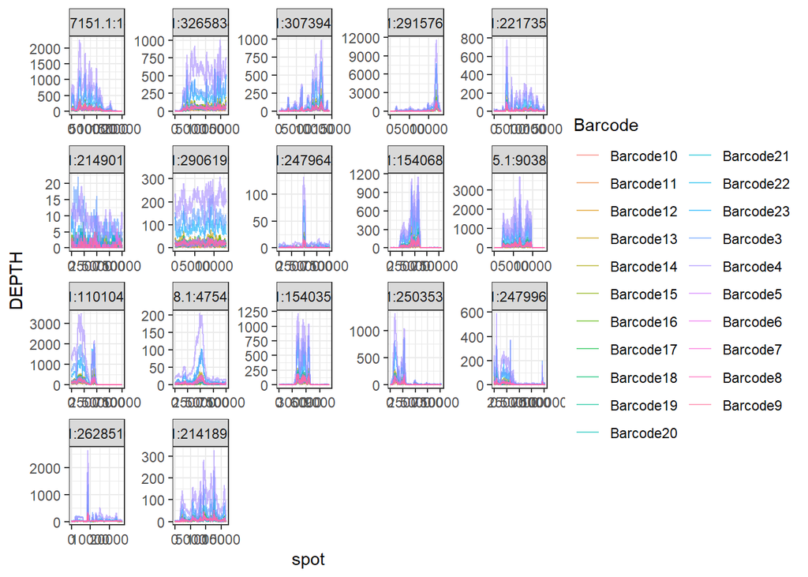

```r
depthall %>%
  separate(col = NAME,into = c("NAME","LENGTH"),sep = ",") %>%
  group_by(NAME,Barcode) %>%
  reframe(spot=POS-min(POS)+1,
            DEPTH=DEPTH) %>%
  filter(!is.na(NAME)) %>%
  ggplot(aes(x=spot,y=DEPTH,color=Barcode))+
  facet_wrap(~NAME,scales = "free")+
  geom_line(alpha=0.6) +
  theme_bw()
```

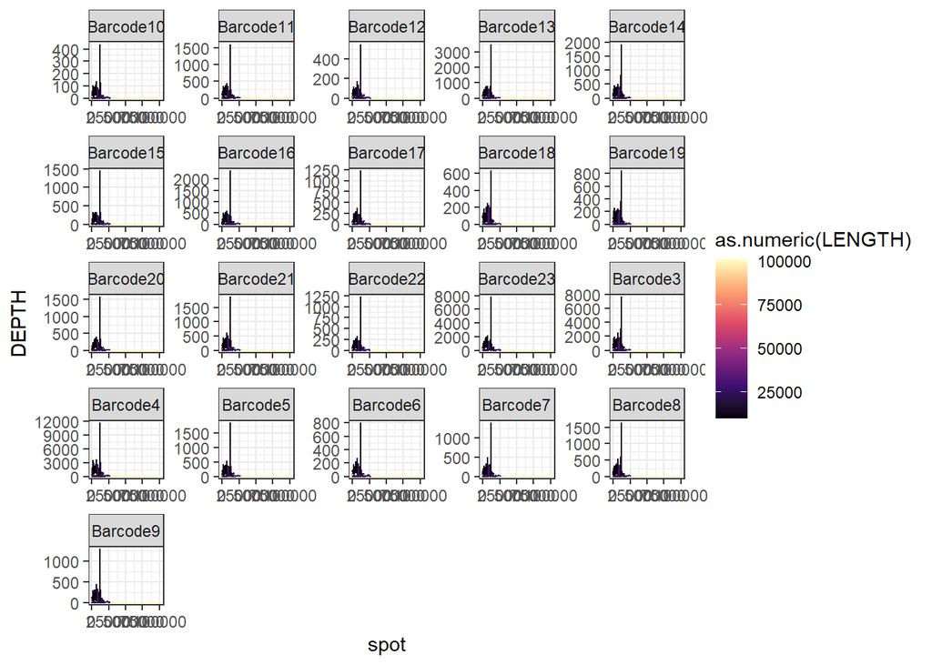

```r
depthall %>%
  separate(col = NAME,into = c("NAME","LENGTH"),sep = ",") %>%
  group_by(NAME,Barcode) %>%
  reframe(spot=POS-min(POS)+1,
          DEPTH=DEPTH,
          LENGTH=LENGTH) %>%
  filter(!is.na(NAME)) %>%
  ggplot(aes(x=spot,y=DEPTH,group=NAME,color=as.numeric(LENGTH)))+
  facet_wrap(~Barcode,scales = "free")+
  geom_line()+
  scale_color_viridis_c(option="magma")+
  theme_bw()
```

```r
##Pairwise plots
# par(mfrow = c(2,3))
# plot(summ1$med1,summ2$med2,xlab = "Barcode 1 - Age 4", ylab = "Barcode 2 - Age 15",xlim = c(0,600),ylim = c(0,600))
# plot(summ1$med1,summ3$med3,xlab = "Barcode 1 - Age 4", ylab = "Barcode 3 - Age 4",xlim = c(0,600),ylim = c(0,600))
# plot(summ1$med1,summ4$med4,xlab = "Barcode 1 - Age 4", ylab = "Barcode 4 - Age 15",xlim = c(0,600),ylim = c(0,600))
# plot(summ2$med2,summ3$med3,xlab = "Barcode 2 - Age 15", ylab = "Barcode 3 - Age 4",xlim = c(0,600),ylim = c(0,600))
# plot(summ2$med2,summ4$med4,xlab = "Barcode 2 - Age 15", ylab = "Barcode 4 - Age 15",xlim = c(0,600),ylim = c(0,600))
# plot(summ3$med3,summ4$med4,xlab = "Barcode 3 - Age 4", ylab = "Barcode 4 - Age 15",xlim = c(0,600),ylim = c(0,600))
```

```r
CpGs_clock <- read.csv("Output/CpGList_LengthAge.csv")

depth_CpGs <- depthall[which(depthall$CHROM == CpGs_clock$CHROM[1] & depthall$POS == CpGs_clock$POS[1]),]

for (i in 2:nrow(CpGs_clock)) {
  depth_CpGs <- rbind(depth_CpGs,depthall[which(depthall$CHROM == CpGs_clock$CHROM[i] & depthall$POS == CpGs_clock$POS[i]),])
}

depth_CpGs$CpG <- paste(depth_CpGs$CHROM,depth_CpGs$POS,sep = "_")

depth_CpGs$Depth <- NA

depth_CpGs$Depth[which(depth_CpGs$DEPTH < 25)] <- "0-25"
depth_CpGs$Depth[which(depth_CpGs$DEPTH >= 25 & depth_CpGs$DEPTH <= 50)] <- "25-50"
depth_CpGs$Depth[which(depth_CpGs$DEPTH > 50 & depth_CpGs$DEPTH <= 100)] <- "50-100"
depth_CpGs$Depth[which(depth_CpGs$DEPTH > 100 & depth_CpGs$DEPTH <= 200)] <- "100-200"
depth_CpGs$Depth[which(depth_CpGs$DEPTH > 200 & depth_CpGs$DEPTH <= 300)] <- "200-300"
depth_CpGs$Depth[which(depth_CpGs$DEPTH > 300)] <- "300+"

tiff(filename = "Figures/NanoporeDepthComp_justCpGs.tiff",width = 150,height = 300,units = "mm",res = 400)
ggplot(depth_CpGs,aes(x=Barcode,y=CpG,fill = Depth))+
  geom_tile(color = "white",
            #lwd = 0.5,
            linetype = 1)+
  facet_wrap(~Barcode,scales = "free_x",ncol = 4)+
  #coord_fixed(expand = FALSE) +
  scale_fill_paletteer_d("nationalparkcolors::Acadia")+
  labs(y = "CpG site in Epigenetic Age Prediction (n = 87)")+
  scale_x_discrete(position = "top") +
  ggtitle("Nanopore Sequencing Depth at Targeted CpG Sites")+
  theme(axis.text.y = element_blank(),axis.ticks = element_blank(),
        axis.title.x = element_blank(),
        axis.text.x = element_blank(),
        axis.title.y = element_text(margin = margin(r = -5), size = 12),
        strip.text = element_text(size = 12,color = "black"),
        strip.background = element_blank(),
        panel.background = element_blank(),
        plot.title = element_text(size = 14,face = "bold"))
dev.off()
```